# Explicit Interaction Community Models

# Simulating species communities

## Simple basic simulation

For testing purposes, you may need to simulate communities with known parameters. We first simulate some occurrence data using a **naive** model where we set the parameters manually, to illustrate the basics. The core function is `as.eicm`, which constructs a model from given coefficients.

```r
nenv <- 2           # 2 environmental predictors
nsp <- 20           # 20 species
nsamples <- 400     # 400 samples

# random responses to environment
env.coefs <- matrix(runif((nenv + 1) * nsp, -4, 4), nrow=nsp)

# let's define some true species interactions
sp.coefs <- matrix(0, nrow=nsp, ncol=nsp)
sp.coefs[3, 5] <- 2  # this reads: species #5 affects species #3 with a "strength" of 2
sp.coefs[4, 1] <- 3
sp.coefs[1, 2] <- -2

# random environmental predictors
env <- matrix(rnorm(nenv * nsamples), ncol=nenv, nrow=nsamples)

# define the true model
true <- as.eicm(env=env, env.coefs=env.coefs, sp.coefs=sp.coefs)

# realize the model
occurrences <- predict(true, nrepetitions=1)

# we now have a plain presence/absence data matrix that follows from the true model
```

## Simulating realistic communities

However, in real communities, *most species are rare*. That is to say, the frequency distribution of species in samples approximately follows a Beta distribution. Simulating realistic communities then requires that this constraint is taken into account. `eicm` provides a function for this purpose.

```r
# Generate a model that, when realized, shows a frequency distribution that
# follows a Beta distribution, yet accounting for all the desired effects
# (including species interactions)

truemodel <- generateEICM(nspecies=32, nsamples=500, nenv=2,
    ninteractions=30, shape1=1.5, shape2=3)
```

Now plot some realizations.

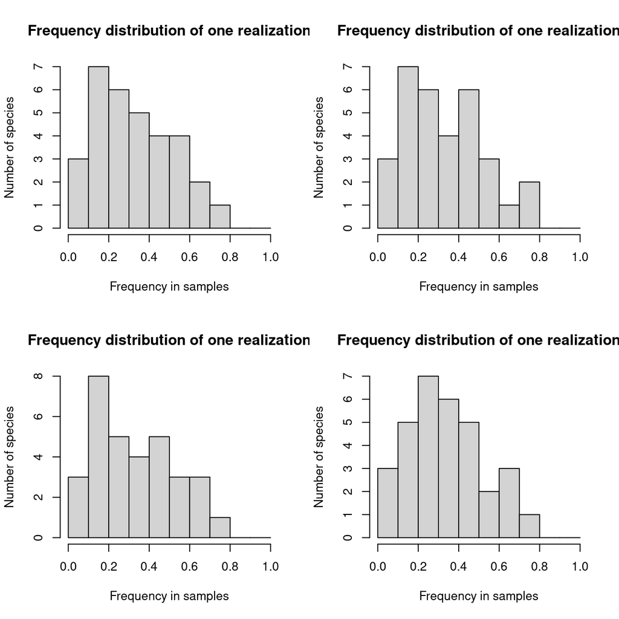

Frequency disrtibutions of four realizations of the same model, generated with generateEICM(…)

```r
# plot frequency histogram of 4 realizations of truemodel:
# should approx. follow a Beta distribution.
par(mfrow=c(2, 2))
for(i in 1:4) {
    occurrences <- predict(truemodel, nrepetitions=1)
    spcounts <- apply(occurrences, 2, sum)

    hist(spcounts / nrow(occurrences), breaks=seq(0, 1, by=0.1), xlim=c(0, 1),
        main="Frequency distribution of one realization", xlab=
        "Frequency in samples",ylab="Number of species")
}
```

[^1]: CIBIO/InBio – Centro de Investigação em Biodiversidade e Recursos Genéticos, Universidade do Porto, Campus de Vairão, 4485-661 Vairão, Portugal; Instituto Superior de Agronomia, Universidade de Lisboa, Tapada da Ajuda, 1349-017 Lisboa, Portugal